# Publication Figure 2

# Libraries

Standard Import

```r
library(tidyverse)
library(cowplot)
library(scales)
library(ggpubr)
```

Special

```r
library(lme4)
library(sjPlot)
library(sjstats)
library(sjlabelled)
```

# Paths

```r
bin_dir = '../bin/'
data_dir = '../data/'
results_dir = '../results/'
```

# Custom Scripts / Theme

```r
source(paste0(bin_dir, 'theme_settings.R'))
source (paste0(bin_dir, 'utilities.R'))
source(paste0(bin_dir, 'species_competition_functions.R'))
source(paste0(bin_dir, 'analysis_metadata.R'))
date <- format(Sys.time(), "%d%m%y")
```

# Import Tables

Metadata

```r
samples.metadata <- read_tsv(paste0(data_dir, 'samples.metadata.tsv'))
microbe.taxonomy <- read_tsv(paste0(data_dir, 'microbe.taxonomy.tsv'))
microbe.metadata <- microbe.taxonomy %>%
  right_join(., read_tsv(paste0(data_dir, 'microbe.metadata.tsv')))
```

## Taxonomy

MetaPhlAn2 tables combine with taxonomy

```r
mp_species.long <- microbe.taxonomy %>%
  right_join(., read_tsv(paste0(data_dir, 'samples.mp_profiles.species.tsv')),
             by = 'species') %>%
  left_join(., samples.metadata, by = 'Name')
```

rCDI subset annotate with metadata

```r
mp_species.rcdi.long <-
  mp_species.long %>%
  filter(Study %in% c(rcdi.studies))
```

## Case Summary

SameStr Case-Summary table

```r
sstr_cases <- read_tsv(paste0(data_dir, 'samples.case_summary.tsv')) %>%
  left_join(., microbe.taxonomy, by = 'species')
```

# Set Figure

```r
fig = paste0('Fig_2.')
```

# Species-level Source

## Mean across Cases

Species-level plot of mean post-FMT rel. abund. by source, using the last available time point of successful FMT cases.

### Format

```r
sstr_cases.source_mean <-
  sstr_cases %>%
  filter(fmt_success, last_sample) %>%

  mutate(unclassified_sp = ifelse(grepl(species, pattern = '_unclassified'),
                                  'unclassified', 'classified')) %>%
  group_by(Study_Type, Case_Name, Days_Since_FMT.post, unclassified_sp) %>%
  summarize_existed(.) %>%

  group_by(Study_Type, unclassified_sp) %>%
  pivot_wider(names_from = 'unclassified_sp', values_from = matches('^[nrf].'),
              names_sep = '.',
              id_cols = c('Study_Type', 'Case_Name', 'Days_Since_FMT.post')) %>%
  select(Study_Type, Case_Name, Days_Since_FMT.post, starts_with('r.')) %>%

  group_by(Study_Type, Case_Name, Days_Since_FMT.post) %>%
  pivot_longer(names_to = 'source', values_to = 'rel_abund', cols = starts_with('r.')) %>%
  ungroup() %>%
  separate(source, into = c(NA,'Sample','source','classified_sp')) %>%

  filter(!source %in% c('either', 'any')) %>%
  mutate(tag.source = case_when(
    classified_sp == 'unclassified' ~ 'Unclassified',
    (Sample == 'donor' & source == 'post') |
    (Sample == 'post' & source == 'donor') ~ 'Donor-Specific',
    (Sample == 'recipient' & source == 'post') |
    (Sample == 'post' & source == 'recipient') ~ 'Recipient-Specific',
    source == 'before' ~ 'Shared R/D',
    source == 'both' ~ 'Same Sp.',
    Sample == 'post' & source == 'unique' ~ 'New',
    T ~ str_to_title(source)
  )) %>%
  mutate(tag.source = as.factor(tag.source)) %>%
  mutate(Sample = str_to_title(str_extract(Sample, pattern = '.'))) %>%

  select(Study_Type, Sample, tag.source, rel_abund) %>%
  group_by(Study_Type, Sample, tag.source) %>%
  summarize_all(.funs = funs(rel_abund.mean = round(mean(., na.rm = T), 2),
                             rel_abund.sd = round(sd(., na.rm = T), 2))) %>%
  ungroup()
```

### Statistics

Data

```r
sstr_cases.samples <-
  sstr_cases %>%
  filter(fmt_success, last_sample) %>%
  select(Study_Type, Study, Case_Name, Sample.recipient, Sample.post, Sample.donor, fmt_success) %>%
  distinct() %>%
  filter(Study_Type == 'rCDI')
paste0('Recipient: ', length(unique(sstr_cases.samples$Sample.recipient)))
```

```
[1] "Recipient: 19"
```

```r
paste0('Post-FMT: ', length(unique(sstr_cases.samples$Sample.post)))
```

```
[1] "Post-FMT: 19"
```

```r
paste0('Donor: ', length(unique(sstr_cases.samples$Sample.donor)))
```

```
[1] "Donor: 14"
```

```r
sstr_cases.source_mean %>%
  pivot_wider(names_from = 'Sample',
              values_from = c('rel_abund.mean', 'rel_abund.sd'),
              names_sep = '.') %>%
  mutate_at(.vars = vars(starts_with('rel_abund')),
            .funs = funs(replace_na(., 0))) %>%
  select(Study_Type, tag.source, ends_with('R'), ends_with('P'), ends_with('D')) %>%
  arrange(desc(Study_Type), desc(rel_abund.mean.P))
```

| Study_Type | tag.source | rel_abund.mean.R | rel_abund.sd.R | rel_abund.mean.P | rel_abund.sd.P | rel_abund.mean.D | rel_abund.sd.D |
| --- | --- | --- | --- | --- | --- | --- | --- |
| rCDI | Same Sp. | 59.01 | 21.74 | 54.41 | 24.82 | 58.27 | 23.61 |
| rCDI | Donor-Specific | 0.00 | 0.00 | 24.95 | 20.15 | 20.79 | 16.24 |
| rCDI | Recipient-Specific | 9.37 | 10.84 | 7.65 | 11.78 | 0.00 | 0.00 |
| rCDI | Unclassified | 3.96 | 7.79 | 2.83 | 6.43 | 2.12 | 8.95 |
| rCDI | New | 0.00 | 0.00 | 1.52 | 1.69 | 0.00 | 0.00 |
| rCDI | Shared R/D | 2.47 | 5.83 | 0.00 | 0.00 | 1.81 | 2.73 |
| rCDI | Unique | 13.22 | 16.38 | 0.00 | 0.00 | 10.51 | 12.27 |
| Control | Recipient-Specific | 88.14 | 8.92 | 88.07 | 9.54 | 0.00 | 0.00 |
| Control | New | 0.00 | 0.00 | 4.52 | 6.78 | 0.00 | 0.00 |
| Control | Unclassified | 2.23 | 4.98 | 1.83 | 3.83 | 0.00 | 0.00 |

[output cut: 4 more lines]

### Pie Chart

Pie chart showing rel. abund. of sets of co-occurring species in recipients, donors, and post-FMT patients. Only a small fraction of post-FMT species has not been observed in the recipient or donor before.

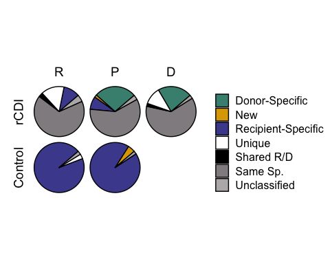

```r
coord_polar_fix <- coord_polar(theta = "y", start = 7.15)
coord_polar_fix$is_free <- function() TRUE

plot <-
  sstr_cases.source_mean %>%
  mutate(tag.source = fct_relevel(tag.source,
                                  'Donor-Specific', 'New', 'Recipient-Specific',
                                  'Unique', 'Shared R/D',
                                  'Same Sp.', 'Unclassified')) %>%
  ggplot(aes(x = fct_relevel(Sample, 'R', 'P', 'D'),
             y = rel_abund.mean, fill = tag.source)) +
  geom_bar(stat = 'identity', position = 'fill', color = 'black') + #
  facet_grid(rows = vars(fct_relevel(Study_Type, 'rCDI')),
             cols = vars(fct_relevel(Sample, 'R', 'P', 'D')),
             scales = 'free', switch = 'y') +
  scale_fill_manual(values = c(colors.discrete[c(1, 2, 3)], 'white', 'black',
                               colors.discrete[c(5, 10)])) +
  theme_cowplot() +

  coord_polar_fix +

  theme(aspect.ratio = 1,
        axis.text = element_blank(),
        axis.title = element_blank(),
        axis.line = element_blank(),
        axis.ticks = element_blank(),
        strip.background = element_blank(),
        panel.spacing = unit(-0.5, "lines"),
        strip.text = element_text(size = 14),
        legend.title = element_blank())

plot
```

Exporting plot

```r
output_name = 'PostSource.Mean_SuccessfulCases.Species'

ggsave(plot + theme(legend.position = 'none'),
       device = 'pdf', dpi = 300, width = 3, height = 2,
       filename = paste0(results_dir, fig, output_name, '.Plot.pdf'))
```

## Case-Wise

Species-level plot of per-Case post-FMT rel. abund. by source

### Format

```r
sstr_cases.source_case <-

  sstr_cases %>%
  mutate(n = 1) %>%

  select(Study_Type, Case_Name, Days_Since_FMT.post, fmt_success.label,
         kingdom, phylum, class, order, family, genus, species,
         n, rel_abund.recipient, rel_abund.post, rel_abund.donor) %>%

  mutate(source = case_when(
    grepl(species, pattern = '_unclassified') ~ 'Unclassified Sp.',
    (rel_abund.recipient > 0) & (rel_abund.donor > 0) & (rel_abund.post == 0) ~ 'Shared Before',
    (rel_abund.recipient > 0) & (rel_abund.donor > 0) & (rel_abund.post > 0) ~ 'Same Sp.',
    (rel_abund.recipient > 0) & (rel_abund.donor == 0) & (rel_abund.post > 0) ~ 'Recipient / Initial Sample',
    (rel_abund.recipient == 0) & (rel_abund.donor > 0) & (rel_abund.post > 0) ~ 'Donor',
    (rel_abund.recipient > 0) & (rel_abund.donor == 0) & (rel_abund.post == 0) ~ 'Unique Recipient',
    (rel_abund.recipient == 0) & (rel_abund.donor > 0) & (rel_abund.post == 0) ~ 'Unique Donor',
    (rel_abund.recipient == 0) & (rel_abund.donor == 0) & (rel_abund.post > 0) ~ 'Unique to Time Point',
    T ~ 'Other'
    )) %>%
  filter(!source %in% c('Unique Donor', 'Unique Recipient', 'Shared Before')) %>%
  filter(rel_abund.post > 0) %>%

  group_by(Study_Type, Case_Name, Days_Since_FMT.post, fmt_success.label) %>%
  mutate(f = n / sum(n, na.rm = T)) %>%
  pivot_longer(names_to = 'metric',
               values_to = 'value',
               cols = c('rel_abund.post', 'n', 'f')) %>%

  group_by(Study_Type, Case_Name, Days_Since_FMT.post, fmt_success.label, source, metric) %>%
  summarize(value = sum(value), .groups = 'drop') %>%

  mutate(value = ifelse(metric == 'rel_abund.post',  value / 100, value),
         metric = case_when(
           metric == 'rel_abund.post' ~ 'Rel. Abund.',
           metric == 'f' ~ 'Spp. Fraction',
           metric == 'n' ~ 'Count of Spp.',
           T ~ 'Other'))
```

### Bar Charts, per Case

rCDI - Bar charts showing post-FMT rel. abund. of sets of co-occurring species in recipients, donors, and post-FMT patients.

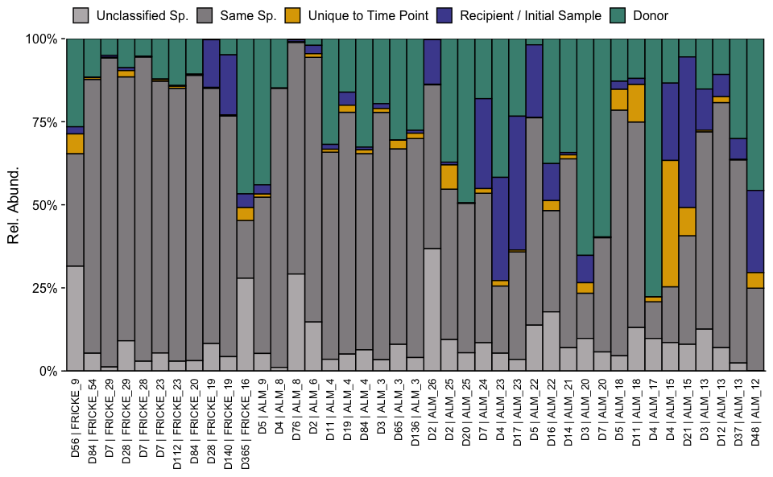

```r
source_order <- c('Donor', 'Recipient / Initial Sample', 'Unique to Time Point', 'Same Sp.')

plot.rcdi <-
  sstr_cases.source_case %>%
  filter(metric == "Rel. Abund.") %>%
  filter(Study_Type == 'rCDI') %>%

  mutate(ordering = -as.numeric(as.factor(Case_Name)) + (Days_Since_FMT.post/1000)) %>%
  ggplot(aes(
    fct_reorder(paste0('D', Days_Since_FMT.post, ' | ', str_remove(Case_Name, pattern = 'Case_')), ordering),
    y = value,
   fill = fct_relevel(source, source_order))) +

   geom_bar(stat = 'identity', position = position_fill(), width = 1, col = 'black') +
  theme_cowplot() +
  scale_y_continuous(labels = percent_format(),
                     breaks = c(1, .75, .5, .25, 0),
                     expand = c(0,0)) +
  scale_fill_manual(values = c(colors.discrete[c(1, 3, 2, 5, 10)]),

                    guide = guide_legend(reverse = TRUE)) +
  labs(y = 'Rel. Abund.') +
  theme(
        axis.title.x = element_blank(),
        axis.line.y = element_blank(),
        axis.text.x = element_text(angle = 90, hjust = 1, vjust = 0.5, size = 10),
        axis.ticks.x = element_blank(),
        legend.title=element_blank(),
        legend.position = 'top')
plot.rcdi
```

Control - Bar charts showing >=second time point rel. abund. of sets of co-occurring species in first and second time points of controls.

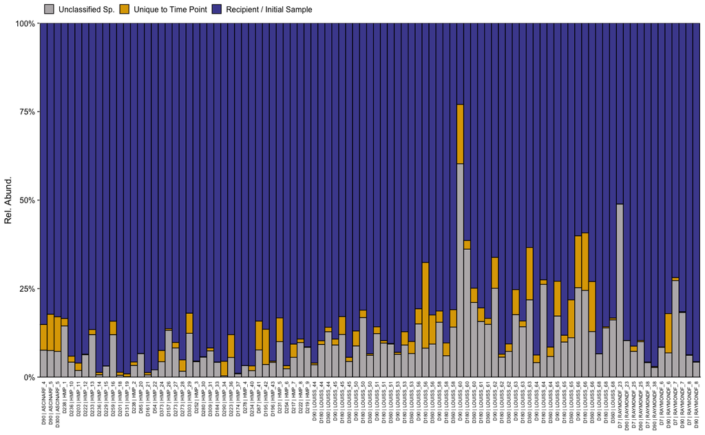

```r
plot.control <-
  sstr_cases.source_case %>%
  filter(metric == "Rel. Abund.") %>%
  filter(Study_Type == 'Control') %>%
  filter(Days_Since_FMT.post <= 373) %>% # ~ same time range as last rcdi

  mutate(ordering = as.numeric(as.factor(Case_Name)) + (Days_Since_FMT.post/1000)) %>%
  ggplot(aes(
    fct_reorder(paste0('D', Days_Since_FMT.post, ' | ', str_remove(Case_Name, pattern = 'Case_')), ordering),
    y = value,
   fill = fct_relevel(source, source_order))) +


  geom_bar(stat = 'identity', position = position_fill(), width = 1, col = 'black') +
  theme_cowplot() +
  scale_y_continuous(labels = percent_format(),
                     breaks = c(1, .75, .5, .25, 0),
                     expand = c(0,0)) +
  scale_fill_manual(values = c(colors.discrete[c(3, 2, 10)]),

                    guide = guide_legend(reverse = TRUE)) +
  labs(y = 'Rel. Abund.') +
  theme(
        axis.title.x = element_blank(),
        axis.line.y = element_blank(),
        axis.ticks.x = element_blank(),
        axis.text.x = element_text(angle = 90, hjust = 1, vjust = 0.5, size = 7.5),
        legend.title=element_blank(),
        legend.position = 'top')
plot.control
```

Exporting plots

```r
output_name = 'PostSource.Cases.rCDI.Species'
ggsave(plot.rcdi + theme(legend.position = 'none'),
       device = 'pdf', dpi = 300, width = 9, height = 3.5,
       filename = paste0(results_dir, fig, output_name, '.Plot.pdf'))
output_name = 'PostSource.Cases.Control.Species'
ggsave(plot.control + theme(legend.position = 'none'),
       device = 'pdf', dpi = 300, width = 25, height = 3.5,
       filename = paste0(results_dir, fig, output_name, '.Plot.pdf'))
```

# Post-FMT Presence/Absence (Species)

Using GLMM to model post-FMT species presence/absence post-FMT. We only have sparse data and single cases for later time points, limiting to <= 84 days

```r
sstr_cases %>%
  filter(Days_Since_FMT.post <= 84) %>%

  filter(Study_Type %in% c('rCDI') ) %>%
  filter(kingdom == 'Bacteria') %>%
  filter(fmt_success) %>%
  distinct(Days_Since_FMT.post) %>%
  summary(.)
```

```
 Days_Since_FMT.post
 Min.   : 2.00
 1st Qu.: 7.00
 Median :17.00
 Mean   :27.94
 3rd Qu.:48.00
 Max.   :84.00
```

### Format

```r
scale_gelman <- function(x) {
  return((x - mean(x)) / (2 * sd(x)))
}

sstr_cases.scaled <-
  sstr_cases %>%

  filter(Study_Type %in% c('rCDI') ) %>%
  filter(kingdom == 'Bacteria') %>%
  filter(fmt_success, Days_Since_FMT.post <= 84) %>%

  mutate(source = ifelse(grepl(species, pattern = 'unclassified'),  'Unclassified', source)) %>%
  mutate(source = case_when(
    analysis_level == 'species' & source == 'self' ~ 'Self Sp.',
    analysis_level == 'species' & source == 'donor' ~ 'Donor Sp.',
    analysis_level == 'species' & source == 'unique' ~ 'Unique Sp.',
    T ~ source
  )) %>%

  left_join(., microbe.metadata) %>%
  mutate(habit.oral = ifelse(is.na(habit.oral), F, habit.oral)) %>%


  mutate(Donor = replace_na(rel_abund.donor > 0, F),
         PostTreatment = replace_na(rel_abund.post > 0, F),
         Pre = replace_na(rel_abund.recipient > 0, F),
         Both = Donor & Pre,
         Any = Donor | Pre) %>%

  mutate(Engrafted = `Donor/Post-FMT.mvs` > min_similarity &
                     `Donor/Post-FMT.overlap` > min_overlap) %>%
  mutate(Engrafted = replace_na(Engrafted, F),
         Engrafted = ifelse(analysis_level == 'species' |
                            grepl(species, pattern = 'unclassified') |
                            !species %in% microbe.metadata$species, NA, Engrafted)) %>%

  # filter only species that existed in any of recipient or donor
  filter(Any) %>%

  rename(OxyTol = 'oxygen.tolerant',
         OxyClass = 'oxygen.class',
         DaysSinceFMT = 'Days_Since_FMT.post',
         Case = 'Case_Name',
         AbundanceDonor = 'rel_abund.donor',
         AbundanceRecipient = 'rel_abund.recipient',
         AbundancePost = 'rel_abund.post') %>%
  mutate(Habitat = ifelse(habit.oral, 'Oral', 'Not-Oral'),
         OxyTol = ifelse(OxyTol, 'Tolerant', 'Not-Tolerant')) %>%
  mutate(Detected = case_when(
    Pre & !Donor ~ 'Recipient',
    !Pre & Donor ~ 'Donor',
    Pre & Donor ~ 'Both')) %>%
  mutate(Specificity = ifelse(Detected == 'Both', F, T)) %>%
  mutate_at(.vars = vars(Case,
                         Specificity,
                         Detected, Engrafted,
                         phylum, class, order, family,
                         OxyTol, OxyClass, Habitat, PostTreatment,
                         ),
            .funs = funs(as.factor(.))) %>%
  mutate(
  Detected = fct_relevel(Detected, 'Recipient'),
  OxyClass = fct_relevel(OxyClass, 'aerobe'),
  Habitat = fct_relevel(Habitat, 'Not-Oral'),
  OxyTol = fct_relevel(OxyTol, 'Not-Tolerant'),
  Phylum = fct_relevel(phylum, 'Firmicutes')
  ) %>%
  select(phylum:species, Engrafted, PostTreatment,
         AbundancePost, Detected, AbundanceDonor, AbundanceRecipient,
         Habitat, OxyTol, DaysSinceFMT, Case, OxyClass) %>%
  mutate(AbundanceDonor = pseudo_log_trans(1e-4, 10)$transform(AbundanceDonor),
         AbundanceRecipient = pseudo_log_trans(1e-4, 10)$transform(AbundanceRecipient),
         AbundanceRatio = AbundanceDonor-AbundanceRecipient,
         DaysSinceFMT = log10(DaysSinceFMT)
         )  %>%
  mutate_at(.vars = vars(starts_with('Abundance'), DaysSinceFMT),
            .funs = funs(scale_gelman(.)))
```

### GLMM Model

Using cases as random effect to account for repeated measurements

```r
fit.rcdi <- glmer(PostTreatment ~
                        Detected +
                        AbundanceDonor +
                        AbundanceRecipient +
                        AbundanceRecipient:AbundanceDonor +
                        Detected:DaysSinceFMT +
                        Detected:Habitat +
                        Detected:OxyTol +
                        (1 | Case),
             family=binomial(link='logit'), data=sstr_cases.scaled)
```

```r
summary(fit.rcdi)
```

```
Generalized linear mixed model fit by maximum likelihood
  (Laplace Approximation) [glmerMod]
 Family: binomial  ( logit )
Formula:
PostTreatment ~ Detected + AbundanceDonor + AbundanceRecipient +
    AbundanceRecipient:AbundanceDonor + Detected:DaysSinceFMT +
    Detected:Habitat + Detected:OxyTol + (1 | Case)
   Data: sstr_cases.scaled

     AIC      BIC   logLik deviance df.resid
  3623.1   3720.9  -1795.5   3591.1     3327

Scaled residuals:
     Min       1Q   Median       3Q      Max
-11.1925  -0.7508   0.2674   0.6836   4.6678

Random effects:
 Groups Name        Variance Std.Dev.
 Case   (Intercept) 0.4556   0.6749
Number of obs: 3343, groups:  Case, 18

Fixed effects:
                                  Estimate Std. Error
(Intercept)                       -0.44457    0.25198
DetectedBoth                       1.87571    0.25020
DetectedDonor                      1.32154    0.22725
AbundanceDonor                     1.55374    0.17499
AbundanceRecipient                 1.73939    0.22868
AbundanceDonor:AbundanceRecipient  1.56730    0.38767
DetectedRecipient:DaysSinceFMT    -1.34464    0.19877
DetectedBoth:DaysSinceFMT         -1.26117    0.20378
DetectedDonor:DaysSinceFMT        -0.02678    0.13706
DetectedRecipient:HabitatOral      0.78386    0.16758
DetectedBoth:HabitatOral          -0.36966    0.24658
DetectedDonor:HabitatOral         -0.65562    0.23629
DetectedRecipient:OxyTolTolerant   0.41526    0.16531
DetectedBoth:OxyTolTolerant       -0.47353    0.24924
DetectedDonor:OxyTolTolerant      -0.50752    0.23443
                                  z value Pr(>|z|)
(Intercept)                        -1.764  0.07768 .
DetectedBoth                        7.497 6.54e-14 ***
DetectedDonor                       5.815 6.05e-09 ***
AbundanceDonor                      8.879  < 2e-16 ***
AbundanceRecipient                  7.606 2.83e-14 ***
AbundanceDonor:AbundanceRecipient   4.043 5.28e-05 ***
DetectedRecipient:DaysSinceFMT     -6.765 1.34e-11 ***
DetectedBoth:DaysSinceFMT          -6.189 6.06e-10 ***
DetectedDonor:DaysSinceFMT         -0.195  0.84509
DetectedRecipient:HabitatOral       4.677 2.90e-06 ***
DetectedBoth:HabitatOral           -1.499  0.13383
DetectedDonor:HabitatOral          -2.775  0.00553 **
DetectedRecipient:OxyTolTolerant    2.512  0.01201 *
DetectedBoth:OxyTolTolerant        -1.900  0.05745 .
DetectedDonor:OxyTolTolerant       -2.165  0.03040 *
---
Signif. codes:
0 ‘***’ 0.001 ‘**’ 0.01 ‘*’ 0.05 ‘.’ 0.1 ‘ ’ 1
```

```
Correlation matrix not shown by default, as p = 15 > 12.
Use print(x, correlation=TRUE)  or
    vcov(x)        if you need it
```

### Forest Plot

```r
a = 'Presence\nBefore FMT'
b = 'Relative\nAbundance'
c = 'Physiology'
d = 'Days\nSince FMT'
e = 'Oral Habitat'
f = 'Oxygen Tolerant'

plot <-
  sjPlot::plot_model(fit.rcdi, se = T,
                     vline.color = "black",
                     wrap.labels = 1e4, # transform = NULL,
            sort.est = F, show.p = T, show.values = T, value.offset = 0.35,
            colors = 'black', axis.title = 'Log of Odds Ratio (95% CI)',
            group.terms = c(a,a, b,b,b, d,d,d, e,e,e, f,f,f),
            title = 'Species Presence Post-FMT'
            ) +
  theme_cowplot() +
  theme(strip.background = element_blank(),
    strip.text.y.left = element_text(angle = 0, hjust = 0),
    plot.title = element_blank(),
    axis.text.y = element_text(size = 11)
    ) +

  facet_grid(rows = vars(fct_relevel(group, a, b, d, e, f)),
             scales = 'free_y', space = 'free_y', switch = 'y') +

    scale_x_discrete(
      labels = c(
        "DetectedBoth" = "Found in Both*",
        "DetectedDonor" = "Donor-Specific*",

        'AbundanceDonor' = 'Donor',
        'AbundanceRecipient' = 'Recipient',
        'AbundanceDonor:AbundanceRecipient' = 'Ratio D/R',

        "DetectedRecipient:DaysSinceFMT" = "Recipient-Specific",
        "DetectedBoth:DaysSinceFMT" = "Found in Both",
        "DetectedDonor:DaysSinceFMT" = "Donor-Specific",
        "DetectedRecipient:HabitatOral" = "Recipient-Specific",
        "DetectedBoth:HabitatOral" = "Found in Both",
        "DetectedDonor:HabitatOral" = "Donor-Specific",

        "DetectedRecipient:OxyTolTolerant" = "Recipient-Specific",
        "DetectedBoth:OxyTolTolerant" = "Found in Both",
        "DetectedDonor:OxyTolTolerant" = "Donor-Specific"
        )
      ) +
   scale_y_continuous(expand = c(0.1,0))
```

```
If standard errors are requested, no transformation is applied to estimates.
for 'x', which will replace the existing scale.
for 'y', which will replace the existing scale.
```

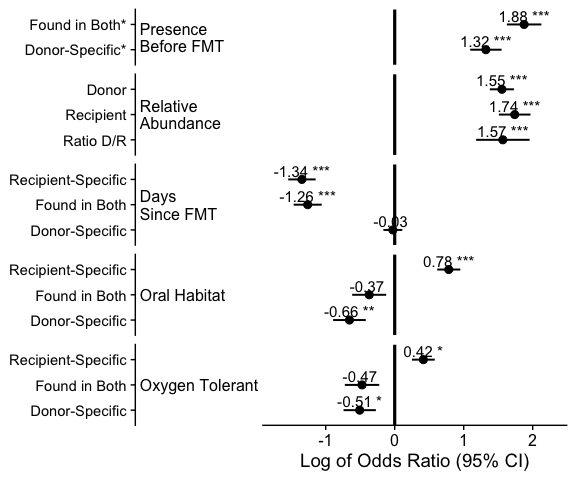

```r
plot
```

Exporting plots, tables

```r
output_name = 'PostPresence.Species.GLMM'

# write model stats to html
sjPlot::tab_model(fit.rcdi, prefix.labels = "varname", transform = NULL,
                  file = paste0(results_dir, fig, output_name, '.Model.html')
                  )

  ggsave(plot + theme(legend.position = 'none'),
       device = 'pdf', dpi = 300, width = 6, height = 5,
       filename = paste0(results_dir, fig, output_name, '.Plot.pdf'))
```